# Project 1 - Avengers

Ye Dam Yi

2/16/2021

This document illustrates the mortality of the Avengers using a colorblind friendly palette. The data are available at https://data.fivethirtyeight.com/.

```r
library(tidyverse)
avengers <- read_csv("data/avengers.csv")
names(avengers)
```

```
##  [1] "URL"                         "Name/Alias"
##  [3] "Appearances"                 "Current?"
##  [5] "Gender"                      "Probationary Introl"
##  [7] "Full/Reserve Avengers Intro" "Year"
##  [9] "Years since joining"         "Honorary"
## [11] "Death1"                      "Return1"
## [13] "Death2"                      "Return2"
## [15] "Death3"                      "Return3"
## [17] "Death4"                      "Return4"
## [19] "Death5"                      "Return5"
## [21] "Notes"
```

```r
glimpse(avengers)
```

```
## Rows: 173
## Columns: 21
## $ URL                           <chr> "http://marvel.wikia.com/Henry_Pym_(Eart…
## $ `Name/Alias`                  <chr> "Henry Jonathan \"Hank\" Pym", "Janet va…
## $ Appearances                   <dbl> 1269, 1165, 3068, 2089, 2402, 612, 3458,…
## $ `Current?`                    <chr> "YES", "YES", "YES", "YES", "YES", "YES"…
## $ Gender                        <chr> "MALE", "FEMALE", "MALE", "MALE", "MALE"…
## $ `Probationary Introl`         <chr> NA, NA, NA, NA, NA, NA, NA, NA, NA, NA, …
## $ `Full/Reserve Avengers Intro` <chr> "Sep-63", "Sep-63", "Sep-63", "Sep-63", …
## $ Year                          <dbl> 1963, 1963, 1963, 1963, 1963, 1963, 1964…
## $ `Years since joining`         <dbl> 52, 52, 52, 52, 52, 52, 51, 50, 50, 50, …
## $ Honorary                      <chr> "Full", "Full", "Full", "Full", "Full", …
## $ Death1                        <chr> "YES", "YES", "YES", "YES", "YES", "NO",…
## $ Return1                       <chr> "NO", "YES", "YES", "YES", "YES", NA, "Y…
## $ Death2                        <chr> NA, NA, NA, NA, "YES", NA, NA, "YES", NA…
## $ Return2                       <chr> NA, NA, NA, NA, "NO", NA, NA, "YES", NA,…
## $ Death3                        <chr> NA, NA, NA, NA, NA, NA, NA, NA, NA, NA, …
## $ Return3                       <chr> NA, NA, NA, NA, NA, NA, NA, NA, NA, NA, …
## $ Death4                        <chr> NA, NA, NA, NA, NA, NA, NA, NA, NA, NA, …
## $ Return4                       <chr> NA, NA, NA, NA, NA, NA, NA, NA, NA, NA, …
## $ Death5                        <chr> NA, NA, NA, NA, NA, NA, NA, NA, NA, NA, …
## $ Return5                       <chr> NA, NA, NA, NA, NA, NA, NA, NA, NA, NA, …
## $ Notes                         <chr> "Merged with Ultron in Rage of Ultron Vo…
```

### Mortality of the Avengers

```r
# create a frequency proportion
death1 <- avengers %>% count(Death1)

# create a percentage variable
death1 <- death1 %>%
  mutate(perc = round(100 * n / sum(n)))
death1 <- death1 %>%
  mutate(perc_perc = paste0(perc, "%"))
death1
```

```
## # A tibble: 2 x 4
##   Death1     n  perc perc_perc
## * <chr>  <int> <dbl> <chr>
## 1 NO       104    60 60%
## 2 YES       69    40 40%
```

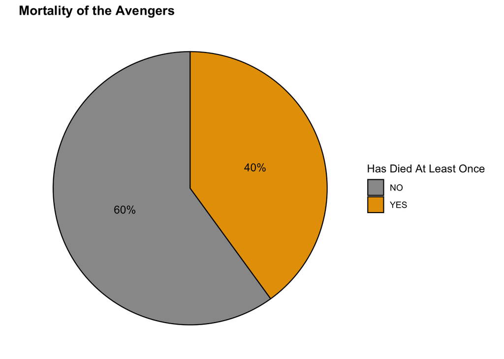

```r
# create color blind friendly palette

# The palette with grey:

cb.palette <- c("#999999", "#E69F00", "#56B4E9", "#009E73", "#F0E442", "#0072B2", "#D55E00", "#CC79A7")

# create a pie chart using the original data set
pie =
  death1 %>%
  ggplot(aes(x = 0, y = perc, fill = Death1)) +
  geom_bar(stat = "identity", color = "black", width = 1) +
  geom_text(aes(label = perc_perc), position = position_stack(vjust = 0.5)) +
  labs(fill = 'Has Died At Least Once',
              x = NULL,
              y = NULL,
              title = 'Mortality of the Avengers'
              ) +
  coord_polar("y") +
  scale_fill_manual(values = cb.palette)

# create a blank theme
blank_theme <-
  theme_void() +
  theme(axis.title.x = element_blank(),
        axis.title.y = element_blank(),
        panel.border = element_blank(),
        panel.grid = element_blank(),
        axis.ticks = element_blank(),
        plot.title = element_text(size = 13, face = "bold"))

# apply blank them
pie + blank_theme
```

This pie chart shows that 40% of the Avengers have died at least once during their mission.

### Mortality of the Avengers by Gender

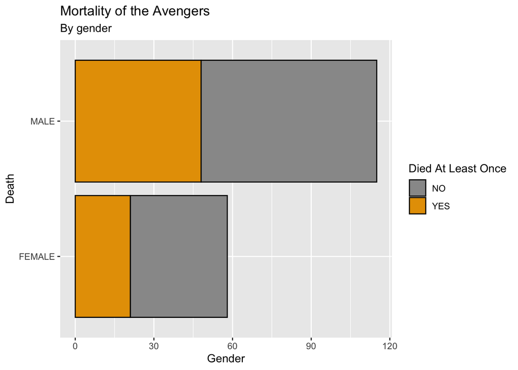

```r
#What's the mortality rate of the Avengers by gender?
avengers %>%
ggplot(mapping = aes(x = Gender, fill = Death1)) +
  geom_bar(colour="black") +
  coord_flip() +
  labs(x = "Death",
       y = "Gender",
       title = "Mortality of the Avengers",
       subtitle = "By gender",
       fill = "Died At Least Once") +
    scale_fill_manual(values=cb.palette)
```

### What I learned

I initially wanted to answer several questions that were addressed in the original article for which the avengers dataset was created. However, I soon found myself struggling with answering the first question about the mortality of the Avengers when I started creating a pie chart.

There were a couple of challenges. First, approaches to creating a pie chart differed across people who shared the code in the Internet. I didn’t know what to choose from, and I tried to put together the different sets of code based on what I understood about them. Second, I couldn’t really understand what the code I saw in the Internet did. I had a vague understanding of each component of the code, so it was difficult for me to write coherent code that would integrate the different approaches I came across. Third, in the middle of creating a pie chart and after putting in several hours into the task, I came across one opinion that it might be better to create a waffle chart than a pie chart for what I was doing. Then, I dabbled at it for a while only to decide I would still create a pie chart because I thought it would be more telling of the data I had and because it would involve using ggplot2, which would help me practice using the package.

I also learned that my approach code needed to change. It was suggested to me that as a literature major who dealt with text and contextual reading all my life, it might not come easily to me that I had to understand every component of written code, instead of focusing on some parts. The suggestion that I might need to adopt a linear, literal, and mechanical interpretation and use of code was enlightening to me because I realized that I had been more liberal in my reading of code.

Learning these lessons, I was able to put together the code for this project by trying to understand what the code others wrote did and adapting it to my own use. Going forward, I would like to remember the following points: 1. I need to practice reading and writing code as literal, sequential, and linear as opposed to metaphorical or metonymic, symbolic, and narrative. 2. I need to pay attention to every component of code I write including a dot. 3. I need to get more familiar with the basic grammar of programming languages.